# Creating Prediction Models for the Africa Soil Property Prediction Challenge Data Set

Adeyemi Arogunmati

May 29, 2016

## Introduction

I have explored the data set Africa Soil Property Prediction Challenge data set (*see the data exploration report*) and see evidence to support that the provided data set can be used to build prediction models for the desired outcome variables (**Sand**, **pH**, **Ca**, **P**, and **SOC**). The goal of this report is to detail my thought process as I explore different models and select the best option based on prediction error, which in this case is the root-mean-squared-error (RMSE). The final pre-processed data set consists of 3579 predictor variables and they are:

- **m7497.96 - m599.76:** 3563 mid-infrared absorbance measurements
- **Depth:** Depth of the soil sample (2 categories: “Topsoil”, “Subsoil”)
- BSA: average long-term Black Sky Albedo measurements from MODIS satellite images (**BSAN** = near-infrared, **BSAS** = shortwave, **BSAV** = visible)
- **CTI:** compound topographic index calculated from Shuttle Radar Topography Mission elevation data
- **ELEV:** Shuttle Radar Topography Mission elevation data
- **EVI:** average long-term Enhanced Vegetation Index from MODIS satellite images.
- LST: average long-term Land Surface Temperatures from MODIS satellite images (**LSTD** = day time temperature, **LSTN** = night time temperature)
- REF: average long-term Reflectance measurements from MODIS satellite images (**REF1** = blue, **REF2** = red, **REF3** = near-infrared, **REF7** = mid-infrared)
- **RELI:** topographic Relief calculated from Shuttle Radar Topography mission elevation data
- **TMAP & TMFI:** average long-term Tropical Rainfall Monitoring Mission data (TMAP = mean annual precipitation, TMFI = modified Fournier index)

After data exploration, I found that the infrared absorbance measurements are the most correlated with our outcome variables while the auxiliary predictor variables (BSA, CTI, ELEV, EVI, LST, REF, RELI, TMAP and TMFI) are weakly or not correlated to the outcome variables except for pH where moderate correlations exists with the predictor variables EVI, TMAP, LSTD, and Ref7.

## Data Loading

Load and prepare data for pre-processing.

```r
## Load Data
data0 <- read.csv(unz("data_and_codes/train.zip","training.csv"), na.strings=c("NA",""))

# Remove spectra CO2 bands
a <- grep("m2379.76",names(data0))
b <- grep("m2352.76",names(data0))

data <- data0[,-seq(a,b)]

## Create spectra-only data subset
infraredCols <- grep("^m[0-9].*?\\.[0-9].*",names(data))
infraredData <- data.frame(data[,infraredCols])
```

## Modeling

Since we will be separating data into predictors variables and outcomes multiple times, define helper functions to accomplish this task. The first function *getFinalData* builds the final data frame from its components: (1) the outcome variable, (2) the Depth column, (3) the decimated infrared measurements column. The second function *createModelingData* performs data creation for the specified outcome variable and decimation parameter using *getFinalData*. In creating the Sand prediction model, I have excluded the auxiliary predictor variables.

```r
# create final data frame based on provided decimation factor
getFinalData <- function (infraredColsData,decimationFactor) {
    decimatedInfrared <- data.frame(t(apply(infraredColsData,1,decimate,decimationFactor)))
    outcomeCols <- grep("Sand|Ca|ph|^P$|SOC|pidn",names(data),ignore.case = TRUE)
    depthCol    <- grep("Depth",names(data),ignore.case = TRUE)
    finalData   <- cbind(data[,outcomeCols],Depth=data[,depthCol],decimatedInfrared)
    finalData
}

# create modeling data for specified outcome variable
createModelingData <- function(outcomeName,infraredColsData,decimationFactor) {
    preparedData <- getFinalData(infraredColsData,decimationFactor)

    if (grepl("sand",outcomeName,ignore.case = TRUE))
        removeCols <- grep("Ca|ph|^P$|SOC|pidn",names(preparedData),ignore.case = TRUE)

    else if (grepl("Ca",outcomeName,ignore.case = TRUE))
        removeCols <- grep("sand|ph|^P$|SOC|pidn", names(preparedData),ignore.case = TRUE)

    else if (grepl("ph",outcomeName,ignore.case = TRUE))
        removeCols <- grep("sand|Ca|^P$|SOC|pidn", names(preparedData),ignore.case = TRUE)

    else if (grepl("^P$",outcomeName,ignore.case = TRUE))
        removeCols <- grep("sand|Ca|ph|SOC|pidn",  names(preparedData),ignore.case = TRUE)

    else if (grepl("SOC",outcomeName,ignore.case = TRUE))
        removeCols <- grep("sand|Ca|ph|^P$|pidn",  names(preparedData),ignore.case = TRUE)

    procData <- preparedData[,-removeCols]
}
```

### 1. Sand

I tested modeling methods: lm (Linear), earth (Multivariate Adaptive Regression Spline), gcvEarth (Multivariate Adaptive Regression Splines), bagEarth (bagged MARS), bagEarthGCV (bagged MARS using gCV pruning), rf (Random Forests). Below is the code sequence I used for modeling Sand outcome with a spectral data decimation factor of 10. I show only the code sequence for this run for brevity because all other similar decimation and modeling method tests follow the same sequence. Subsequently, I will only show summary results.

```r
## train model for sand prediction given data decimation factor of 10
set.seed(1234)
procData <- createModelingData("sand",infraredData,10)
inTrain  <- createDataPartition(y=procData$Sand, p=0.75, list=FALSE)

trainingSand <- procData[inTrain,]
testingSand  <- procData[-inTrain,]

fitSand.lm.10          <- train(Sand ~ ., method="lm",          data=trainingSand)
fitSand.bagEarth.10    <- train(Sand ~ ., method="bagEarth",    data=trainingSand)
fitSand.bagEarthGCV.10 <- train(Sand ~ ., method="bagEarthGCV", data=trainingSand)
fitSand.earth.10       <- train(Sand ~ ., method="earth",       data=trainingSand)
fitSand.gcvEarth.10    <- train(Sand ~ ., method="gcvEarth",    data=trainingSand)
fitSand.rf.10          <- train(Sand ~ ., method="rf",          data=trainingSand)
```

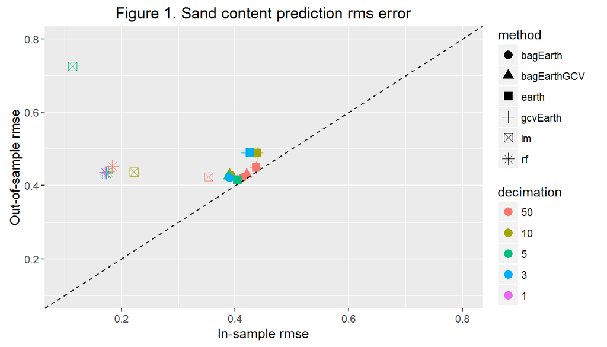

We can see from Figure 1 that the errors vary more with training method than decimation factors. In fact, for rf and bagEarthGCV method, there isn’t much difference in prediction rms errors. Random forest and linear regression methods produced results with in-sample errors not reflective of out-of-sample errors.

Example prediction plots are shown below.

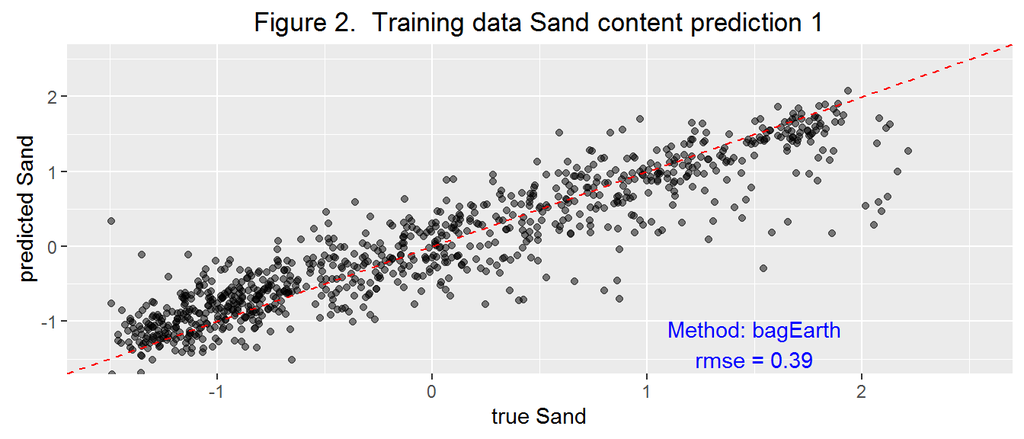

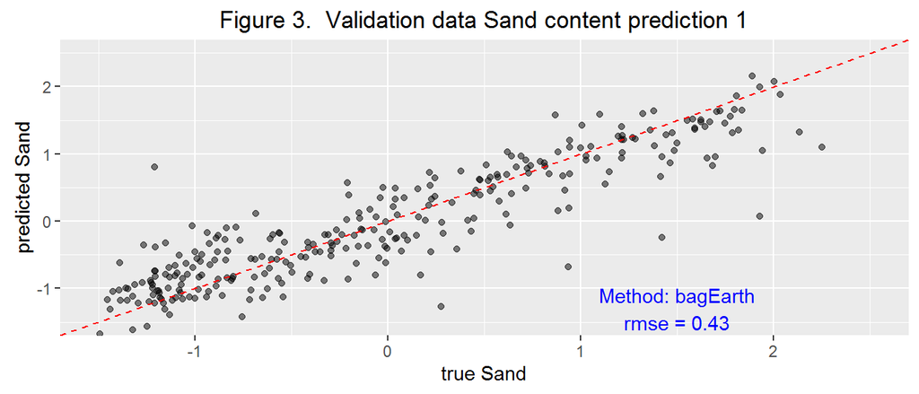

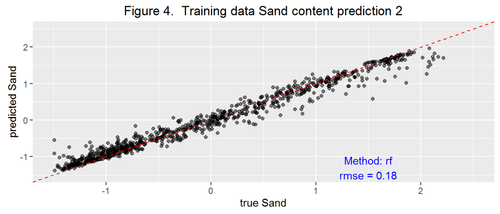

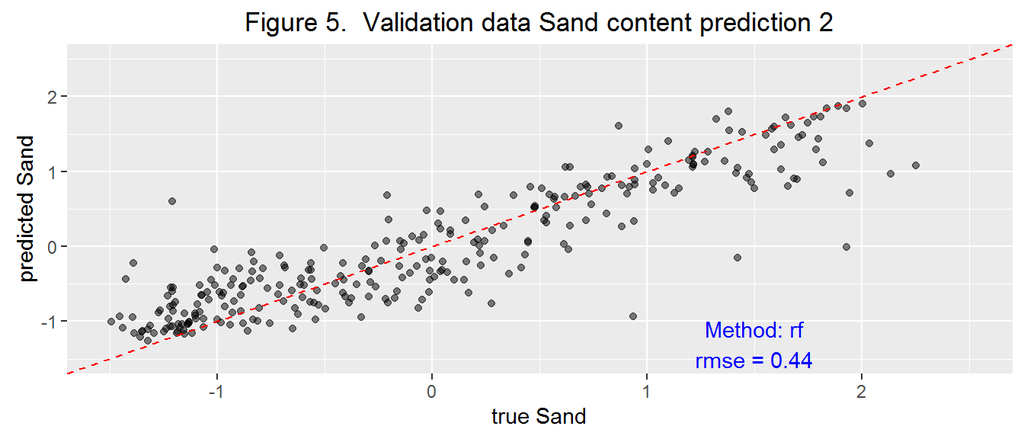

### 2. SOC

Just as with the Sand content, I tested several decimation factors and modeling methods for the SOC measure. Results are shown below.

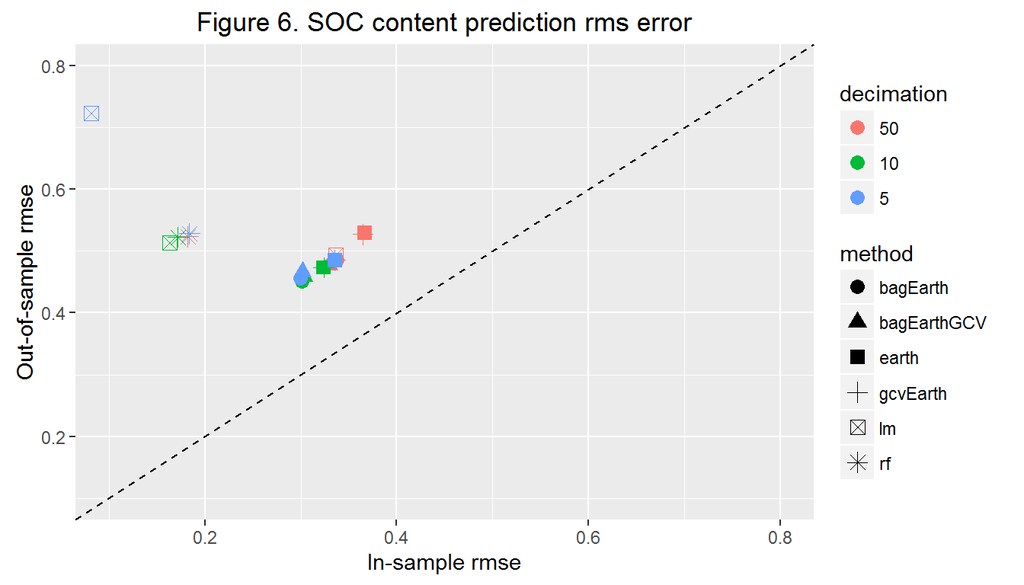

Figure 6 shows in-sample errors less than 0.4 and out-of-sample errors less than 0.6 with the exception of the linear regression model for the SOC variable. Example prediction plots are shown below.

Example prediction plots are shown below.

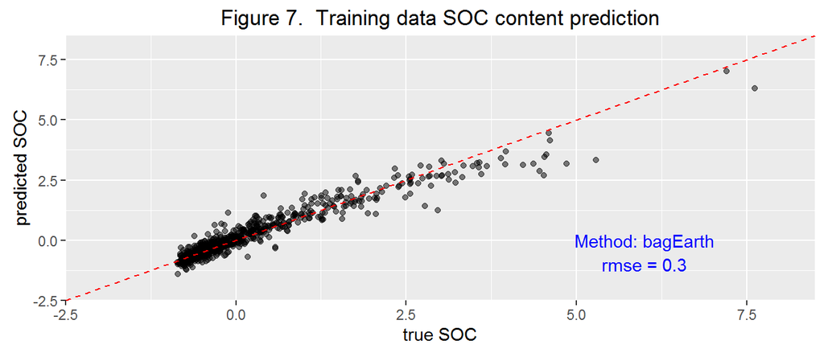

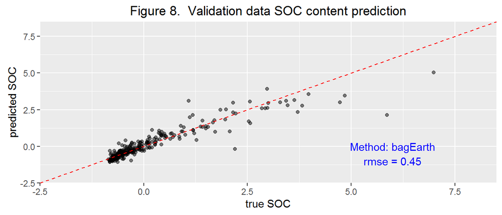

### 3. Ca

Prediction error plots showing outcome of decimation tests for Ca are shown below.

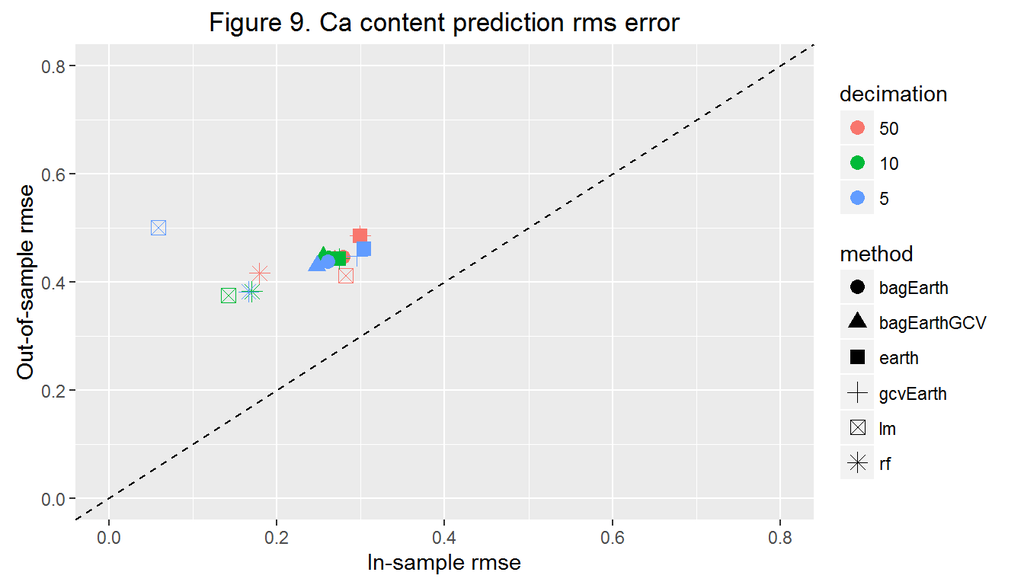

Example prediction plots are shown below.

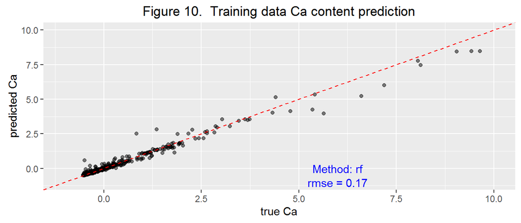

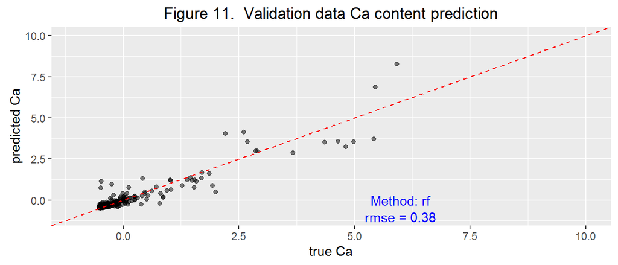

### 4. P

Prediction error plots of decimation tests for P are shown below.

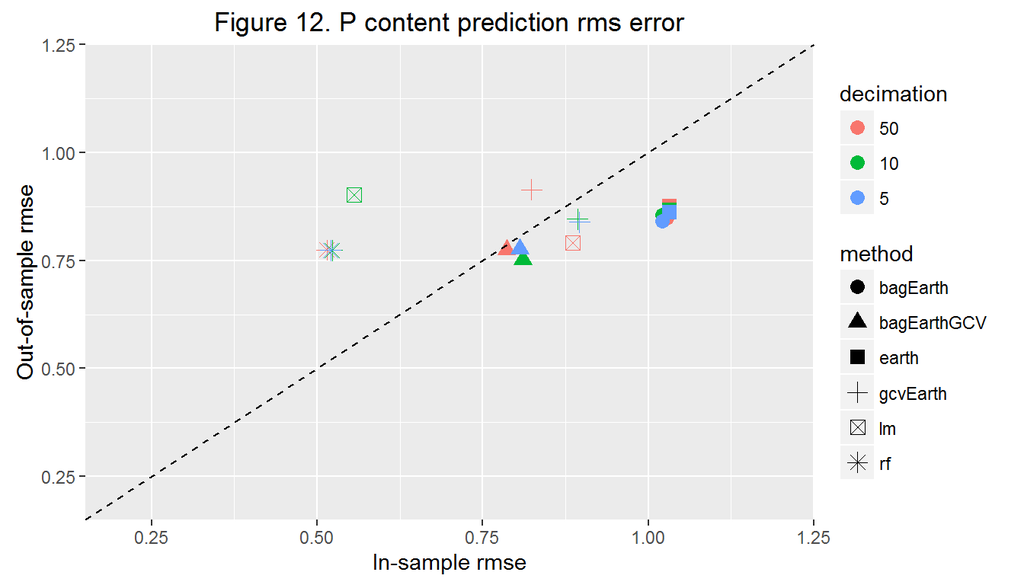

It appears from Figure 12 that the predictor variables are not good predictors of P. Out-of-sample errors are lower than in-sample errors in some cases which does not make sense given the data set. Let’s take a look at some prediction plots.

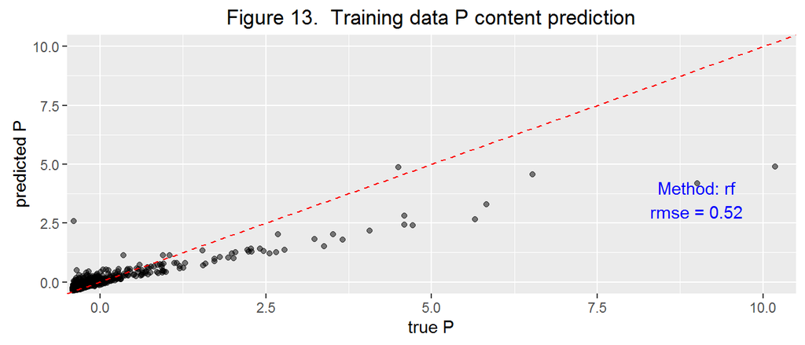

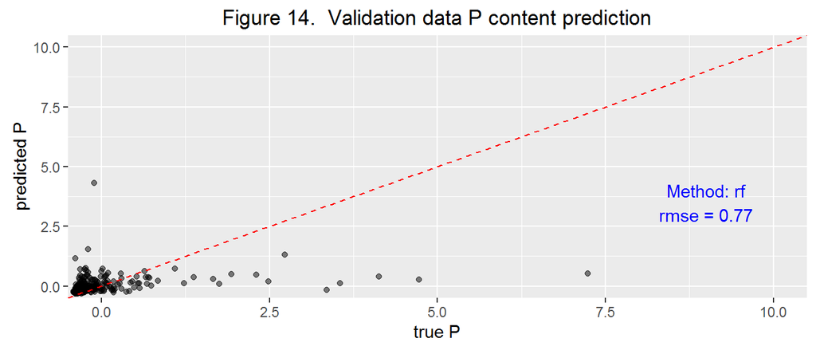

As expected, our prediction model does not explain the data to an acceptable degree. One way to solve this problem is to fine tune our modeling parameters or seek additional data to better predict P from the spectral data provided.

### 5. pH

In modeling pH, we will consider the case where auxiliary predictor variables (EVI, TMAP, LSTD, REF7) are included in training and the case where they are not. During exploratory analysis, moderate correlation between pH and the auxiliary variables was seen.

#### 5a. Without auxilliary variables

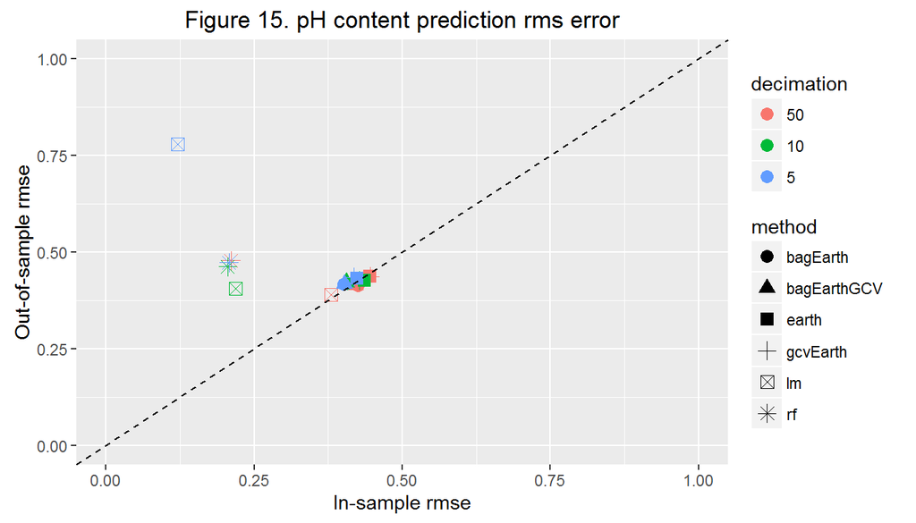

We can see in Figure 15 that with the exception of random forest and linear regression methods, all methods produce results with out-of-sample errors that mimic the in-sample errors. That’s a good generalization. In addition, points cluster around the same location regardless of decimation factor for earth, bagEarth, bagEarthGCV, and gcvEarth methods.

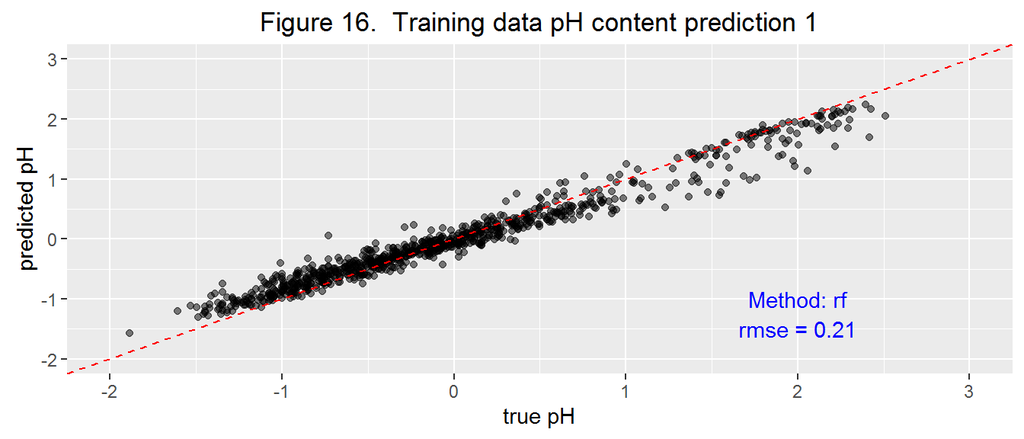

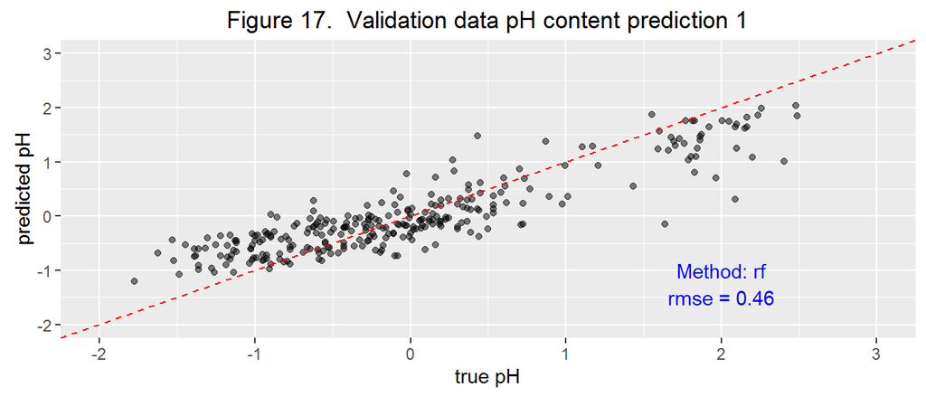

#### 5b. With auxilliary variables

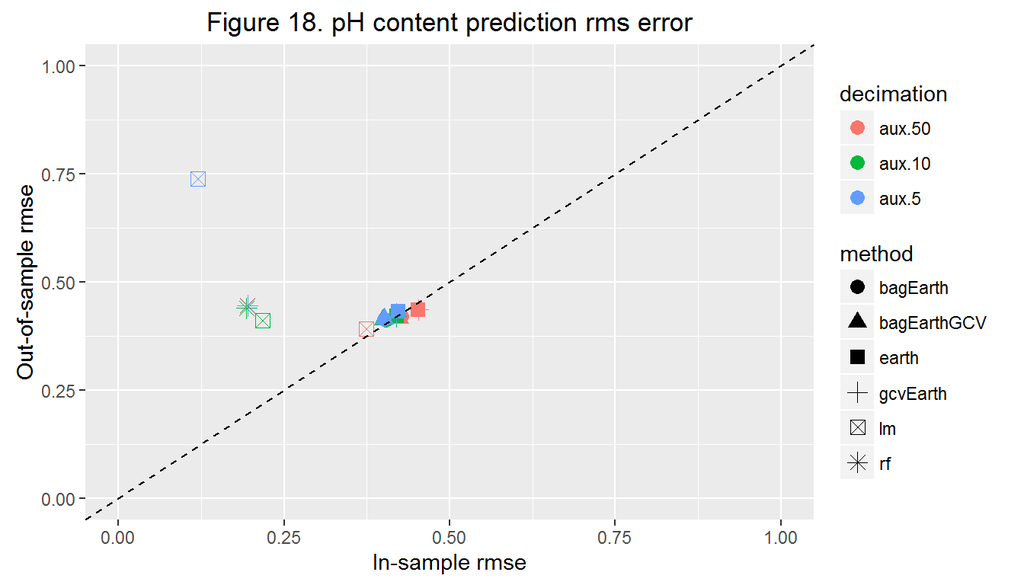

Figure 18 shows improvements in in-sample and out-of-sample error due to the inclusion of the auxiliary variables in predicting pH. This observation was expected as we saw the moderate correlation of pH with the auxiliary variables during exploratory data analysis.

Below are examples of predicted data using the updated model.

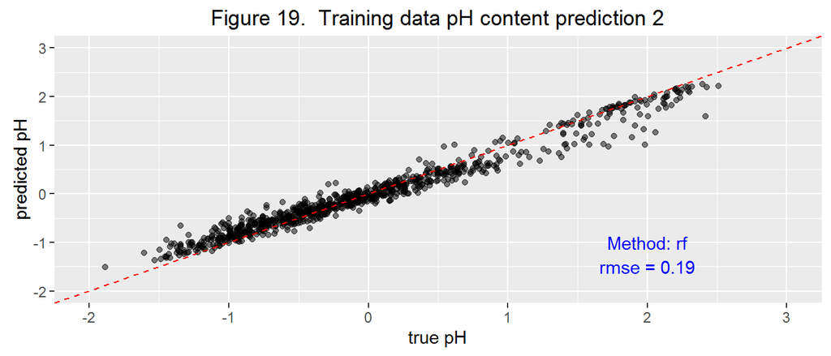

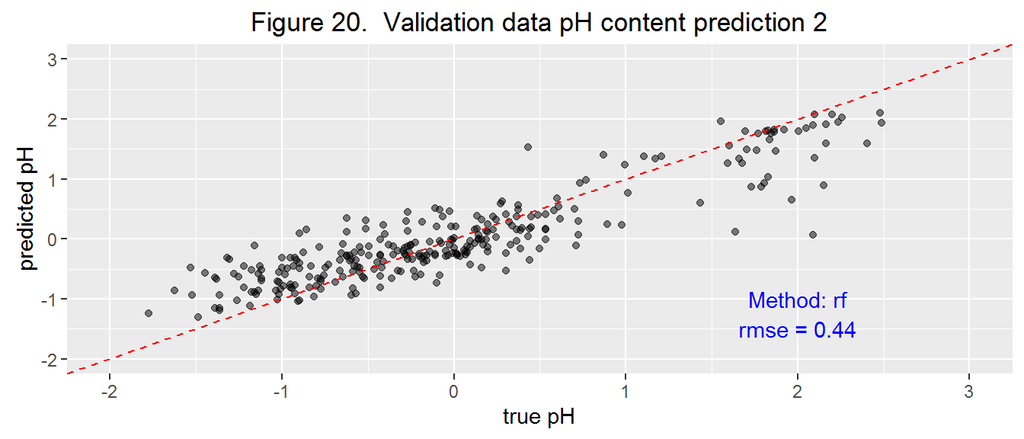

## Conclusions

In conclusion, I have shown through numerous tests that diffuse reflectance infrared spectroscopy can be used to predict sand content, Mehlich-3 extractable calcium, pH values and organic carbon in soils. However, I was unable to model relationships between the spectral data and Mehlich-3 extractable phosphorus. From initial exploratory data analysis, it was evident that any relationship between them will be tough to model.

Secondly, by decimating the data in such a way that aliasing is avoided, it was possible to reduce the number of predictor variables by up to a factor of 50 and still obtain reasonable results. This would be impossible if aliasing effects were not considered. Reducing the number of predictor variables from over 3500 to less than 100 definitely saves computation time.

Thirdly, for the pH outcome variable, including auxiliary predictor variables EVI (average long-term Enhanced Vegetation Index from MODIS satellite images), TMAP (mean annual precipitation), LSTD (day time temperature), and REF7 (average long-term Reflectance measurements from MODIS satellite images - mid-infrared), helped improve prediction errors. The possibility of this improvement was first observed during exploratory data analysis through computed cross-correlation values.